# Machine Learning Course Project

Dec 27, 2015

## Summary

The following analysis will train three machine learning models using the training data from the pml-training.csv file and test its predictive abilities on the testing data from the pml-testing.csv file. The goal is to predict the manner in which the participants performed their exercise. Note to the reader, the actual R output percentages may be slightly different than the percentages in the writeup because the R code was run prior to completing this R Markdown document. Since this is a classification problem, the “RMSE” metric is not used, and a simple error metric (1.0 - Accuracy Rate) is used instead.

## Load Libraries and Prepare Multicore Processing

This analysis was performed on an 8 core workstation with 32GB of RAM. At its peak, the analysis consumed nearly 10GB of RAM. If the reader were to run this analysis, please do so on a workstation with enough memory. The parallel library was used to exploit multiple cores in the analysis. If the reader were to run this analysis, please adjust the number of clusters/core to match your workstation’s specification. The following libraries below are required for this analysis.

```r
library(rlist)
library(caret)
library(data.table)
library(dplyr)
library(randomForest)
library(ggplot2)
library(parallel)
library(doParallel)
registerDoParallel(makeCluster(8, type = 'SOCK'))
```

## Loading the Data Set

The training and testing files were downloaded and placed on a local drive. The files are loaded from the local drive for convenience and to reduce data loading time. The classification labels from the training data set are shown below. There are five unique output labels.

```r
setwd("D:/coursera/pml")
train.data <- read.csv("pml-training.csv", header = TRUE, na.strings=c("","NA", "#DIV/0!"))
test.data <- read.csv("pml-testing.csv", header = TRUE, na.strings=c("","NA", "#DIV/0!"))
levels(train.data$classe)
```

```
## [1] "A" "B" "C" "D" "E"
```

## Helper Functions

The converNumeric function is used convert vectors to numeric types. The pml_write_files function is used to output the results of trained models on the test data sets to external text files.

```r
convertNumeric <- function(x){ for(i in 1:(length(x)-1)){x[,i] <- as.numeric(x[,i])}
  return (x) }

pml_write_files <- function(x){
  n = length(x)
  for(i in 1:n){
    filename = paste0("problem_id_",i,".txt")
    write.table(x[i],file=filename,quote=FALSE,row.names=FALSE,col.names=FALSE)
  }
}
```

## Data Set Preparation

Before training and using the models, the raw datasets need to be cleaned. The raw datasets contain N/A values. More specifically, some columns in both data sets contain all N/A values. Those columns are identified and removed with the following code. The number of columns/variables were reduced from 160 to 60 including the output variable, “classe”. The reduced column/variable names are presented below.

```r
naColumns <- sapply(train.data, function (x) any(is.na(x) | x == ""))
valid.columns <- names(naColumns[naColumns==FALSE])
valid.columns
```

```
##  [1] "X"                    "user_name"            "raw_timestamp_part_1"
##  [4] "raw_timestamp_part_2" "cvtd_timestamp"       "new_window"
##  [7] "num_window"           "roll_belt"            "pitch_belt"
## [10] "yaw_belt"             "total_accel_belt"     "gyros_belt_x"
## [13] "gyros_belt_y"         "gyros_belt_z"         "accel_belt_x"
## [16] "accel_belt_y"         "accel_belt_z"         "magnet_belt_x"
## [19] "magnet_belt_y"        "magnet_belt_z"        "roll_arm"
## [22] "pitch_arm"            "yaw_arm"              "total_accel_arm"
## [25] "gyros_arm_x"          "gyros_arm_y"          "gyros_arm_z"
## [28] "accel_arm_x"          "accel_arm_y"          "accel_arm_z"
## [31] "magnet_arm_x"         "magnet_arm_y"         "magnet_arm_z"
## [34] "roll_dumbbell"        "pitch_dumbbell"       "yaw_dumbbell"
## [37] "total_accel_dumbbell" "gyros_dumbbell_x"     "gyros_dumbbell_y"
## [40] "gyros_dumbbell_z"     "accel_dumbbell_x"     "accel_dumbbell_y"
## [43] "accel_dumbbell_z"     "magnet_dumbbell_x"    "magnet_dumbbell_y"
## [46] "magnet_dumbbell_z"    "roll_forearm"         "pitch_forearm"
## [49] "yaw_forearm"          "total_accel_forearm"  "gyros_forearm_x"
## [52] "gyros_forearm_y"      "gyros_forearm_z"      "accel_forearm_x"
## [55] "accel_forearm_y"      "accel_forearm_z"      "magnet_forearm_x"
## [58] "magnet_forearm_y"     "magnet_forearm_z"     "classe"
```

The number of columns/variables are further reduced by removing the first seven columns. These variables are related to time stamps, username, and other non-essential predictors. The corresponding columns with the exception of the “classe” variables are removed from the test data. Both the training and testing data are converted to numeric.

```r
train.columns <- valid.columns[-(1:7)]
test.columns <-  valid.columns[-(1:7)]
test.columns <- test.columns[-53] #The "classe" column/variable is not present in the testing data

train.data <- train.data[,train.columns] %>% convertNumeric
test.data <- test.data[,test.columns] %>% convertNumeric
```

## Create training and validation/testing subsets

```r
set.seed(5134)
train.index <- createDataPartition(y=train.data$classe, p=0.7, list=FALSE)
training.subset <- train.data[train.index,]   #Training Subset
validation.subset <- train.data[-train.index,]  #Validation/Testing Subset
```

## Dimension Reduction through Principal Component Analysis

The number of columns/variables are still too excessive. We want to reduce the dimensionality of the problem by using principal component analysis on the training subset. We plot a scree diagram and a cumulative proportional variance diagram below. From the scree plot, the first 10 eigenvalues are significant. Morever, on the second diagram, we see that the first 10 principal components explain 96% of the variance in the training subset. The first 18, 28, and 32 principal components explain 99.1%, 99.92%, & 99.98% of the variance in the training subset, respectively. The exact percentages are found in the activity.pca.propvar variable.

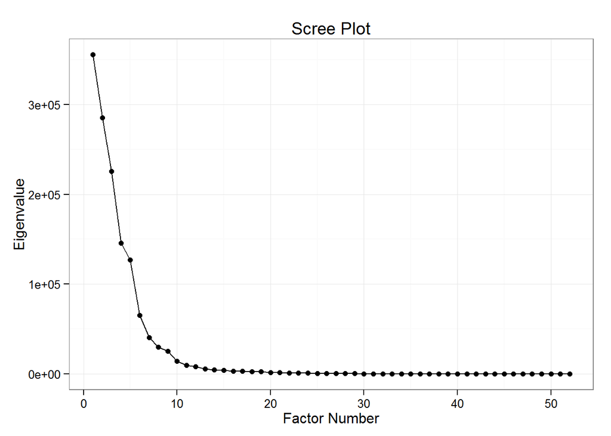

```r
activity.pca <- prcomp(training.subset[,-53], retx=TRUE, scale. = FALSE, center=TRUE)
activity.pca.data <- data.frame(PC=1:length(activity.pca$sdev), Variance=activity.pca$sdev^2)
activity.pca.propvar <- (activity.pca$sdev^2/sum(activity.pca$sdev^2)) %>% cumsum
## Add back the original output labels to the 18 pca data frame
activity.pca.propvar <- data.frame(x=1:length(activity.pca.propvar), cumvar=activity.pca.propvar)

g1<-ggplot(activity.pca.data, aes(x=PC, y=Variance))+
  geom_point() +
  geom_line() +
  xlab("Factor Number")+
  ylab("Eigenvalue")+
  theme(legend.position = "none") +
  ggtitle("Scree Plot") +
  theme_bw()

g2<-ggplot(activity.pca.propvar, aes(x=x, y=cumvar))+
  geom_bar(stat="identity") +
  xlab("Number of Components")+
  ylab("Proportion of Variance Explained")+
  theme_bw()

plot(g1)
```

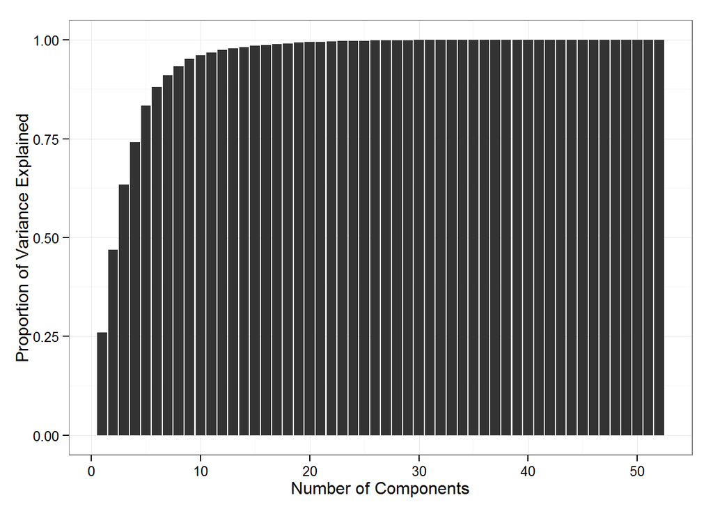

```r
plot(g2)
```

Instead of using the original testing subset, we use the first 18 principal components i.e. the eigenvectors of the covariance matrix of the original testing subset. To prevent cheating and bias in the training of the models, Principal Component Analysis is only applied to the training subset. This produces a vector of centers for each of the principal components along with a rotation matrix. The vector of centers/means is subtracted from each component for every observation in the validation subset to apply zero mean centering. To apply the transformation from the training subset, the rotation matrix is applied to the zero mean validation matrix to produce corresponding principal component matrices that are analogous to the training subset’s PC matrix.

```r
#nPCA = 32
#nPCA = 20
#nPCA = 28
nPCA = 18
## We use the principal components of the dataset instead of the original dataset
training.subset.pca <- cbind(as.data.frame(activity.pca$x[,1:nPCA]), classe=training.subset$classe)

# Apply Zero Centering and Rotation to Validation test using the same transformation from the training set
#subtract mean of each component from the observations and multiple by rotation matrix from testing subset
tmp <-  sweep(validation.subset[,1:52],2,activity.pca$center)
validation.subset.pca <- as.matrix(tmp) %*% activity.pca$rotation
# Add the output lables from the original validation subset
validation.subset.pca <- cbind(as.data.frame(validation.subset.pca[,1:nPCA]), classe=validation.subset$classe)
```

## Random Forest on PCA Data

A random forest model is trained using the first 18 principal components of the testing subset. The caret package is used for convenience with a 5 fold cross validation scheme to train the random forest model. The best trained random forest model gives an accuracy of 96.65852% on the pca training subset. The error on the training subset is 3.3415%. The sample sizes for the cross validation subsets are presented below. To test the accuracy of the trained random forest model, the first 18 principal componets of the validation subset are used as predictors. We analyze the results using a confusion matrix and see that the accuracy of the trained model on the validation subset is quite good at 97.47%. The out of sample error is 2.53%.

```r
#########RF#########################
set.seed(1299)
rf.model.pca <- train(classe~., data = training.subset.pca, method ="rf", metric = "Accuracy", trControl=trainControl(method="cv", number = 5))
rf.model.pca
```

```
## Random Forest
##
## 13737 samples
##    18 predictor
##     5 classes: 'A', 'B', 'C', 'D', 'E'
##
## No pre-processing
## Resampling: Cross-Validated (5 fold)
## Summary of sample sizes: 10988, 10991, 10989, 10991, 10989
## Resampling results across tuning parameters:
##
##   mtry  Accuracy   Kappa      Accuracy SD  Kappa SD
##    2    0.9663671  0.9574426  0.003783035  0.004778737
##   10    0.9622899  0.9522811  0.005898813  0.007458254
##   18    0.9469300  0.9328354  0.004373567  0.005535780
##
## Accuracy was used to select the optimal model using  the largest value.
## The final value used for the model was mtry = 2.
```

```r
# use model to predict on validation data set
rf.prediction.pca <- predict(rf.model.pca, validation.subset.pca)
# predicted result
confusionMatrix(rf.prediction.pca, validation.subset.pca$classe)
```

```
## Confusion Matrix and Statistics
##
##           Reference
## Prediction    A    B    C    D    E
##          A 1655   16    1    3    1
##          B    4 1105   21    1   12
##          C    6   14  995   34    4
##          D    6    0    4  922    7
##          E    3    4    5    4 1058
##
## Overall Statistics
##
##                Accuracy : 0.9745
##                  95% CI : (0.9702, 0.9784)
##     No Information Rate : 0.2845
##     P-Value [Acc > NIR] : < 2.2e-16
##
##                   Kappa : 0.9678
##  Mcnemar's Test P-Value : 3.598e-06
##
## Statistics by Class:
##
##                      Class: A Class: B Class: C Class: D Class: E
## Sensitivity            0.9886   0.9701   0.9698   0.9564   0.9778
## Specificity            0.9950   0.9920   0.9881   0.9965   0.9967
## Pos Pred Value         0.9875   0.9668   0.9449   0.9819   0.9851
## Neg Pred Value         0.9955   0.9928   0.9936   0.9915   0.9950
## Prevalence             0.2845   0.1935   0.1743   0.1638   0.1839
## Detection Rate         0.2812   0.1878   0.1691   0.1567   0.1798
## Detection Prevalence   0.2848   0.1942   0.1789   0.1596   0.1825
## Balanced Accuracy      0.9918   0.9811   0.9789   0.9765   0.9872
```

## K-Nearest Neighbors on PCA Data

```r
set.seed(3521)
knn.model.pca <- train(classe~., data = training.subset.pca, method ="knn", metric = "Accuracy", trControl=trainControl(method="cv", number = 5))
knn.model.pca
```

```
## k-Nearest Neighbors
##
## 13737 samples
##    18 predictor
##     5 classes: 'A', 'B', 'C', 'D', 'E'
##
## No pre-processing
## Resampling: Cross-Validated (5 fold)
## Summary of sample sizes: 10990, 10990, 10989, 10989, 10990
## Resampling results across tuning parameters:
##
##   k  Accuracy   Kappa      Accuracy SD  Kappa SD
##   5  0.8692575  0.8345584  0.006202491  0.007839448
##   7  0.8472738  0.8067056  0.003450097  0.004352358
##   9  0.8298754  0.7846513  0.005383694  0.006754240
##
## Accuracy was used to select the optimal model using  the largest value.
## The final value used for the model was k = 5.
```

```r
knn.predictionPCA <- predict(knn.model.pca, validation.subset.pca)
confusionMatrix(knn.predictionPCA, validation.subset.pca$classe)
```

```
## Confusion Matrix and Statistics
##
##           Reference
## Prediction    A    B    C    D    E
##          A 1572   67   13   24   19
##          B   27  929   45   12   44
##          C   18   55  929   70   33
##          D   43   43   23  841   52
##          E   14   45   16   17  934
##
## Overall Statistics
##
##                Accuracy : 0.8845
##                  95% CI : (0.876, 0.8925)
##     No Information Rate : 0.2845
##     P-Value [Acc > NIR] : < 2.2e-16
##
##                   Kappa : 0.8539
##  Mcnemar's Test P-Value : 5.705e-15
##
## Statistics by Class:
##
##                      Class: A Class: B Class: C Class: D Class: E
## Sensitivity            0.9391   0.8156   0.9055   0.8724   0.8632
## Specificity            0.9708   0.9730   0.9638   0.9673   0.9808
## Pos Pred Value         0.9274   0.8789   0.8407   0.8393   0.9103
## Neg Pred Value         0.9757   0.9565   0.9797   0.9748   0.9695
## Prevalence             0.2845   0.1935   0.1743   0.1638   0.1839
## Detection Rate         0.2671   0.1579   0.1579   0.1429   0.1587
## Detection Prevalence   0.2880   0.1796   0.1878   0.1703   0.1743
## Balanced Accuracy      0.9549   0.8943   0.9346   0.9198   0.9220
```

## Gradient Boosting on PCA Data

The ensemble learner, Stochastic Gradient Boosting,is trained using the same pca test subset with a 5 fold cross validation. This gives an accuracy of 81.58256% on the pca training subset. The error on the training subset is 18.41744%. The trained GBM model is tested against the PCA validation subset and achieved an accuracy of 82.55%. The out of sample error is 17.45%. The GBM model did not perform as well as either the Random Forest or KNN models. The number of principal components were increased from 20 to 28, and 32 for the training and validation subset. However, the model was never able to achieve accuracy greater than 88% on either the training or validation subset. The outputs of using increasing number of principal components are not show for brevity.

```r
set.seed(5287)
gbm.model.pca <- train(classe~., data = training.subset.pca, method ="gbm", metric = "Accuracy", trControl=trainControl(method="cv", number = 5))
```

```r
gbm.model.pca
```

```
## Stochastic Gradient Boosting
##
## 13737 samples
##    18 predictor
##     5 classes: 'A', 'B', 'C', 'D', 'E'
##
## No pre-processing
## Resampling: Cross-Validated (5 fold)
## Summary of sample sizes: 10988, 10990, 10989, 10990, 10991
## Resampling results across tuning parameters:
##
##   interaction.depth  n.trees  Accuracy   Kappa      Accuracy SD
##   1                   50      0.5747982  0.4556425  0.009642912
##   1                  100      0.6210953  0.5171693  0.008259189
##   1                  150      0.6460644  0.5501754  0.006133833
##   2                   50      0.6539297  0.5595711  0.010213252
##   2                  100      0.7168977  0.6408412  0.010007045
##   2                  150      0.7542409  0.6883030  0.008385326
##   3                   50      0.7047407  0.6250650  0.009172271
##   3                  100      0.7748444  0.7144534  0.010431451
##   3                  150      0.8177201  0.7689698  0.006223367
##   Kappa SD
##   0.012177750
##   0.010038124
##   0.007249559
##   0.012667178
##   0.012347468
##   0.010323419
##   0.011414905
##   0.012965075
##   0.007722441
##
## Tuning parameter 'shrinkage' was held constant at a value of 0.1
##
## Tuning parameter 'n.minobsinnode' was held constant at a value of 10
## Accuracy was used to select the optimal model using  the largest value.
## The final values used for the model were n.trees = 150,
##  interaction.depth = 3, shrinkage = 0.1 and n.minobsinnode = 10.
```

```r
# use model to predict on validation data set
gbm.predictionPCA <- predict(gbm.model.pca, validation.subset.pca)
# predicted result
confusionMatrix(gbm.predictionPCA, validation.subset.pca$classe)
```

```
## Confusion Matrix and Statistics
##
##           Reference
## Prediction    A    B    C    D    E
##          A 1536  117   50   50   39
##          B   33  856   75   18   83
##          C   32   91  852  100   61
##          D   48   35   30  776   74
##          E   25   40   19   20  825
##
## Overall Statistics
##
##                Accuracy : 0.8233
##                  95% CI : (0.8133, 0.8329)
##     No Information Rate : 0.2845
##     P-Value [Acc > NIR] : < 2.2e-16
##
##                   Kappa : 0.776
##  Mcnemar's Test P-Value : < 2.2e-16
##
## Statistics by Class:
##
##                      Class: A Class: B Class: C Class: D Class: E
## Sensitivity            0.9176   0.7515   0.8304   0.8050   0.7625
## Specificity            0.9392   0.9560   0.9416   0.9620   0.9783
## Pos Pred Value         0.8571   0.8038   0.7500   0.8058   0.8881
## Neg Pred Value         0.9663   0.9413   0.9634   0.9618   0.9481
## Prevalence             0.2845   0.1935   0.1743   0.1638   0.1839
## Detection Rate         0.2610   0.1455   0.1448   0.1319   0.1402
## Detection Prevalence   0.3045   0.1810   0.1930   0.1636   0.1579
## Balanced Accuracy      0.9284   0.8537   0.8860   0.8835   0.8704
```

For Comparison purposes, the Stochastic Gradient Boosting model was trained using the original training subset with 5 fold cross validation. This gives an accuracy of 95.88% on the training subset. The error on the training subset is 4.12%. The accuracy of the trained model on the validation subset is 96.04%. The out of sample error is 3.96%. The outputs of the GBM model and confusion matrix are not shown for brevity.

```r
set.seed(5287)
gbm.model <- train(classe~., data = training.subset, method ="gbm", metric = "Accuracy", trControl=trainControl(method="cv", number = 5))
gbm.model
gbm.prediction <- predict(gbm.model, validation.subset)
confusionMatrix(gbm.prediction, validation.subset$classe)
```

## Testing Data Set

The vector of means/centers from the training subset is subtracted from each component for every observation in the training data to apply zero mean centering. To apply the transformation from the training subset, the rotation matrix is applied to the zero mean testing matrix to produce corresponding principal component matrices that are analogous to the training subset’s PC matrix.

```r
tmp <-  sweep(test.data[,1:52],2,activity.pca$center) ##subtract mean of each component from the observations
test.data.pca <- as.matrix(tmp) %*% activity.pca$rotation
test.data.pca <- as.data.frame(test.data.pca[,1:nPCA])
```

We run the transformed pca tesing data through the random forest, k-nearest neighbor, and stochastic gradient boosting models. From the results below, it seems that the random forest and KNN were able to produce idential predictions, while the boosting model produced slightly different predictions. The author submitted the results from the random forest prediction, and they were all correct. This implies that the predictions from the KNN model was also correct. The predictions for the 20 test cases are shown below.

```r
rf.test.subset.pca.output <- predict(rf.model.pca, test.data.pca)
knn.test.subset.pca.output <- predict(knn.model.pca, test.data.pca)
gbm.test.subset.pca.output <- predict(gbm.model.pca, test.data.pca)

rf.test.subset.pca.output
```

```
##  [1] B A B A A E D B A A B C B A E E A B B B
## Levels: A B C D E
```

```r
knn.test.subset.pca.output
```

```
##  [1] B A B A A E D B A A B C B A E E A B B B
## Levels: A B C D E
```

```r
gbm.test.subset.pca.output
```

```
##  [1] C A A A A E D D A A B C E A E E A B B B
## Levels: A B C D E
```

```r
identical(rf.test.subset.pca.output,gbm.test.subset.pca.output)
```

```
## [1] FALSE
```

```r
identical(rf.test.subset.pca.output,knn.test.subset.pca.output)
```

```
## [1] TRUE
```

```r
identical(gbm.test.subset.pca.output,knn.test.subset.pca.output)
```

```
## [1] FALSE
```

For completeness, the original non-pca testing data set was run through the vanilla non-pca stochastic boosting model and the model was able to produce accurate predictions similar to those of the pca random forest and pca KNN models.

```r
gbm.test.subset.output <- predict(gbm.model, test.data)
gbm.test.subset.output
```

```
##  [1] B A B A A E D B A A B C B A E E A B B B
## Levels: A B C D E
```

```r
identical(gbm.test.subset.output,gbm.test.subset.pca.output)
```

```
## [1] FALSE
```

```r
identical(rf.test.subset.pca.output,gbm.test.subset.output)
```

```
## [1] TRUE
```

```r
identical(gbm.test.subset.output,knn.test.subset.pca.output)
```

```
## [1] TRUE
```

## Conclusion

After cleaning the original training and testing datasets and removing unnecessary variables/columns, principal component analysis was performed on the remaining variables. The number of variables were reduced from 52 to 18. After performing the same transformation to the validation subset & original testing data, and training the three models on the reduced pca subset with 5 fold cross validation, we showed that both the random forest and KNN models were able to accurately predict the 20 test cases from the testing data. However, the stochastic gradient boosting model was not able to produce accurate predictions despite training with an increasing number of principal components on the training subset (i.e. 20,28,32 principal componets). The stochastic gradient boosting algorithm was only able to produce an accurate prediction when it was trained on the original non-pca training subset and non-pca testing set.

Of the three models, Random Forest was able to achieve the best results on the reduced dimensioned PCA datasets. Stochastic Gradient Boosting did not perform well with the reduced dimension pca dataset but did provide better results with the original data sets. It seems that from the results of this experiment that an ensemble of weak learners requires more predictors for better performance.

## Test Cases Submission

This section outputs the predictions by the random forest model for the 20 test cases to text files for submission to coursera.

```r
#output classification to text file
pml_write_files(rf.test.subset.pca.output)
```